# uav_lidar_inventory

Author

Teja Kattenborn (teja.kattenborn@geosense.uni-freiburg.de)

Published

November 16, 2024

# Drone-based LiDAR Forest Inventory

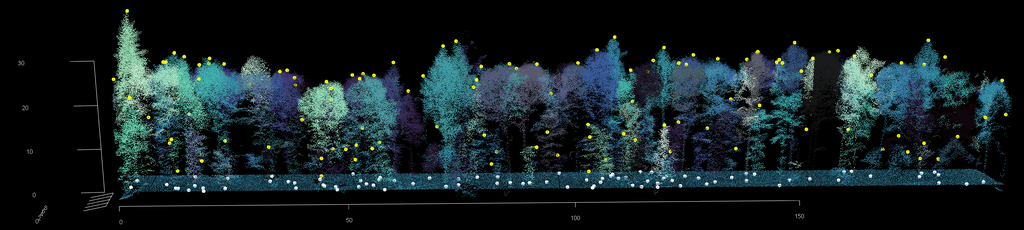

## Load Packages, paths, etc…

```r
#install.packages(c("lidR","RCSF", "gstat", "viridis))
library(lidR)
library(RCSF)
library(gstat)
library(viridis)
library(dplyr)
```

Set the path to your data

```r
wdir <- "//unfnrd02.public.ads.uni-freiburg.de/unfnrd02/teaching/data/ecosense_lidar/l2_60m_gassilloud_2024/"
```

## Read and inspect the las-file

```r
las
```

```
class        : LAS (v1.4 format 6)
memory       : 661.3 Mb
extent       : 416677.3, 416893.8, 5346656, 5346869 (xmin, xmax, ymin, ymax)
coord. ref.  : NA
area         : 38304 units²
points       : 12.38 million points
density      : 323.29 points/units²
```

```r
summary(las)
```

```
class        : LAS (v1.4 format 6)
memory       : 661.3 Mb
extent       : 416677.3, 416893.8, 5346656, 5346869 (xmin, xmax, ymin, ymax)
coord. ref.  : NA
area         : 38304 units²
points       : 12.38 million points
density      : 323.29 points/units²
File signature:           LASF
File source ID:           0
Global encoding:
 - GPS Time Type: GPS Week Time
 - Synthetic Return Numbers: no
 - Well Know Text: CRS is GeoTIFF
 - Aggregate Model: false
Project ID - GUID:        00000000-0000-0000-0000-000000000000
Version:                  1.4
System identifier:
Generating software:      LASzip DLL 3.4 r3 (191111)
File creation d/y:        321/2024
header size:              375
Offset to point data:     813
Num. var. length record:  1
Point data format:        6
Point data record length: 33
Num. of point records:    12383167
Num. of points by return: 0 0 0 0 0 0 0 0 0 0 0 0 0 0 0
Scale factor X Y Z:       0.001 0.001 0.001
Offset X Y Z:             416677.3 5346656 501.3455
min X Y Z:                416677.3 5346656 501.3825
max X Y Z:                416893.8 5346869 569.1675
Variable Length Records (VLR):
   Variable Length Record 1 of 1
       Description:
       Extra Bytes Description:
          PredSemantic:
          PredInstance:
Extended Variable Length Records (EVLR):  void
```

## Visualizing LAS files

### Basic plotting

Then use the plot function. The plot function is lidR::plot but we can just use plot since R knows that this is an lidR object. If you run this command an external window will open where you can pan and rotate the point cloud.

```r
plot(las, axis = TRUE)
```

### Visualize segmented point cloud

First we check how many trees were found and initialize colors for all trees

```r
# first we initialize colors for all trees
# How much trees do we have?
n_trees <- length(unique(las@data$PredInstance))
#col <- random.colors(2070)
col <- sample(viridis(2070, option = "mako"))
```

```r
plot(las, color = "PredInstance", pal = col, axis = TRUE, nbreaks = length(col))
```

## Find coordinates for each tree

Tree positions are usually defined by the stem coordinate. However, our point cloud does not yet have a unique coordinate for each tree but many coordinates (a point cloud for each tree). You can see this once you plot some single trees (also a good chance to get an idea of the segmentation quality):

```r
example_tree <- 1107 # select a tree ID of your choice

las_instance <- filter_poi(las, PredInstance == randomtree)
plot(las_instance, color = "Z")
```

One solution to extract stem coordinates is to only extract points from tree stems and use their centroid.

[figure not shown]

So we could just slice ourn point cloud to extract all stems (e.g. from 0 to 4 m height). However, our point cloud has Z values (heights) over sea level and we also have some topographic variation in our area. Thus, we cannot just use the point cloud heights as they are, since these are not yet tree heights.

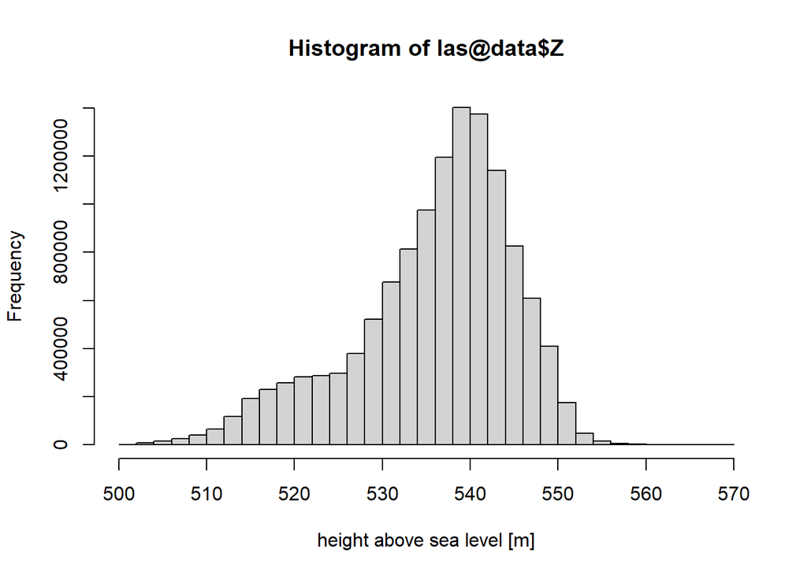

```r
hist(las@data$Z, xlab = "height above sea level [m]")
```

Anyway, normalizing point clouds (removing terrain heights) is a standard operation. We first define the terrain and then subtract the terrain height from the points, before we can use them to extract height information.

### Height normalization via Digital terrain model (DTM)

lidR has a built-in classifier to detect ground points:

```r
mycsf <- csf(TRUE, 1, 1, time_step = 1)
las <- classify_ground(las, mycsf)
```

Only keep (filter) and plot the ground points:

```r
ground_points <- filter_poi(las, Classification == 2)
plot(ground_points, axis = TRUE)
```

That looks good! Now we can built a 2D raster from this (discrete matrix):

```r
dtm <- rasterize_terrain(las, 1, knnidw(k = 6L, p = 2))
dtm
```

```
class       : SpatRaster
dimensions  : 214, 217, 1  (nrow, ncol, nlyr)
resolution  : 1, 1  (x, y)
extent      : 416677, 416894, 5346656, 5346870  (xmin, xmax, ymin, ymax)
coord. ref. :
source(s)   : memory
name        :        Z
min value   : 502.0345
max value   : 525.4125
```

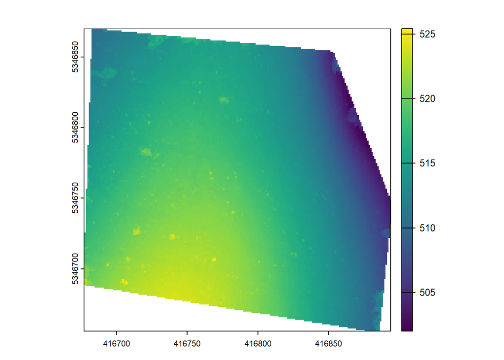

```r
plot(dtm)
```

Now we can for each point in the point cloud calculate the height difference to the DTM cell, which will result in a new point cloud (the normalized point cloud)

```r
nlas <- normalize_height(las, dtm)
```

Let´s see if it worked. Is the topography removed and do the axis seem to correspond to actual tree heights?

```r
plot(nlas, axis = T)
```

```r
nlas <- normalize_height(las, knnidw()) # fast
```

[output not shown]

```r
#nlas <- normalize_height(las, knnidw(k = 8, p = 2))
#nlas <- normalize_height(las, kriging()) # slow
```

Let´s see if also this approach seems to work:

```r
plot(nlas, axis = T)
```

### Extract tree stems and extract their individual coordinates

Let´s slice the normalized point cloud between the ground and some meters height:

```r
nlas_trans <- filter_poi(nlas, Z >= 0.1 & Z <= 4)
```

Check the output (feel free to play with the numbers):

```r
#col <- random.colors(2070)
col <- sample(viridis(2070, option = "mako"))
plot(nlas_trans, color = "PredInstance", pal = col, legend = F, axis = T, nbreaks = length(col))
```

Now that we have the stems, let´s determine the centroid for each tree

```r
# Calculate centroids for each instance
centroids <- nlas_trans@data %>%
  group_by(PredInstance) %>%
  summarize(
    X = mean(X),
    Y = mean(Y),
    Z = 0,
    .groups = "drop"  # Avoid unnecessary grouping in the result
  )

# Print centroids
print(centroids)
```

```
# A tibble: 1,672 × 4
   PredInstance       X        Y     Z
          <int>   <dbl>    <dbl> <dbl>
 1            0 416780. 5346781.     0
 2            1 416795. 5346756.     0
 3            5 416689. 5346868.     0
 4            6 416692. 5346868.     0
 5            7 416686. 5346864.     0
 6            8 416684. 5346845.     0
 7           10 416685. 5346840.     0
 8           11 416683. 5346847.     0
 9           13 416683. 5346852.     0
10           15 416687. 5346852.     0
# ℹ 1,662 more rows
```

Let´s inspect the outcome:

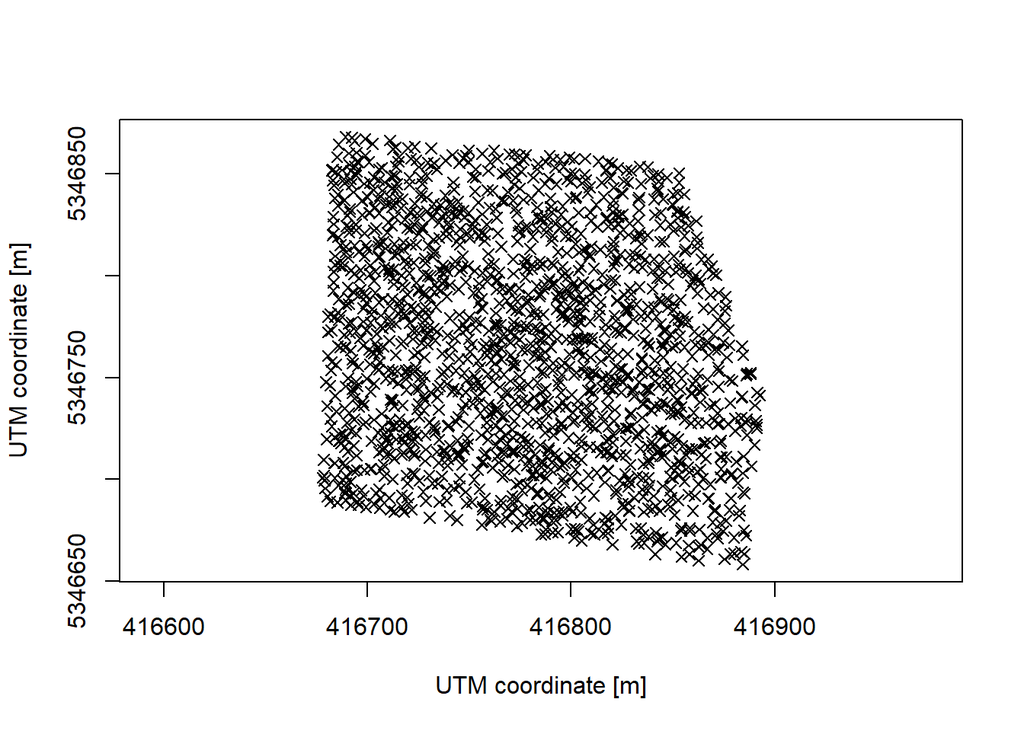

```r
plot(centroids$X, centroids$Y, pch = 4, asp = 1,
     xlab = "UTM coordinate [m]", ylab = "UTM coordinate [m]")
```

```r
centro_las <- LAS(centroids)
```

```r
col <- sample(viridis(2070, option = "mako"))
p <- plot(nlas_trans, color = "PredInstance", pal = col, legend = F, axis = T, nbreaks = length(col))
```

```r
plot(centro_las, add = p, pal = "white", size = 10)
```